# Indel Signature InsDel19a

# InsDel19a

(corresponds to 83-type signature C_ID19)

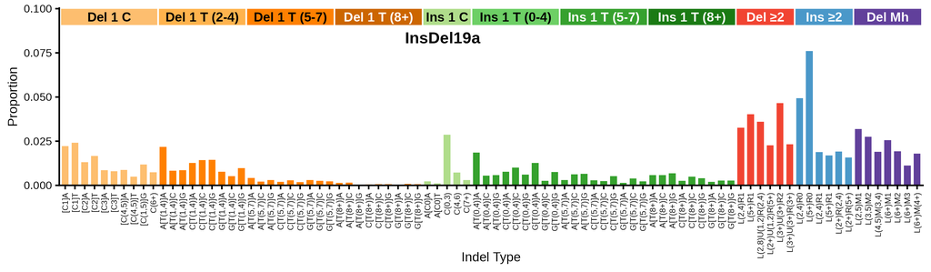

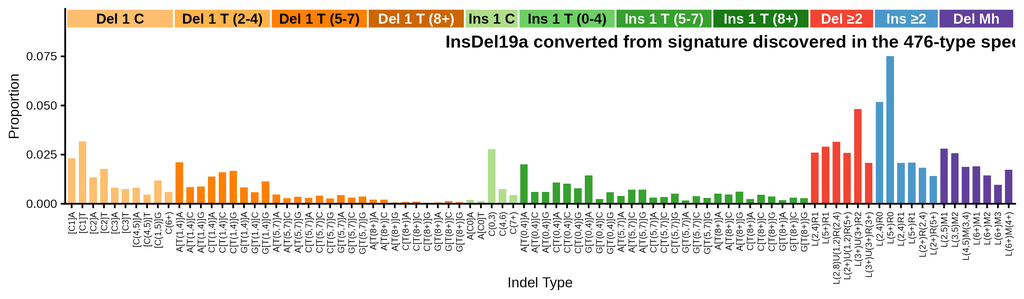

89-type spectrum of the linking tumor CPCT02010408TII | cosine similarity to InsDel19a: 0.9494

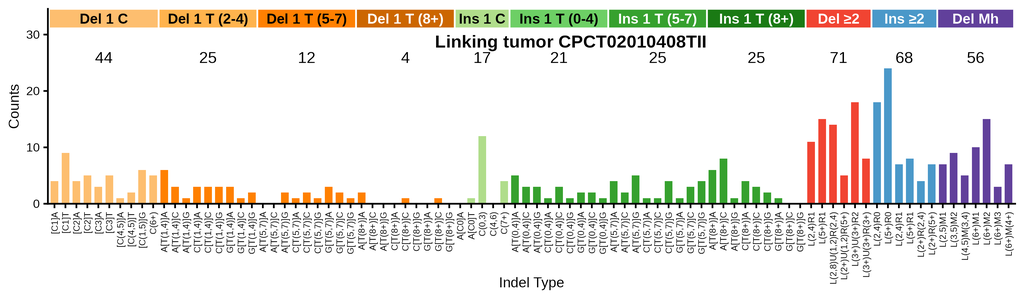

**Click to view decomposition of the linking tumor spectrum**

Partial mutation signature of CPCT02010408TII due to InsDel19a

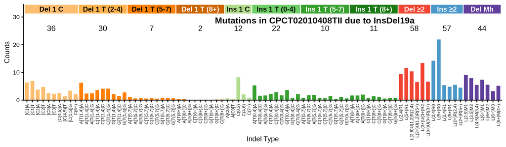

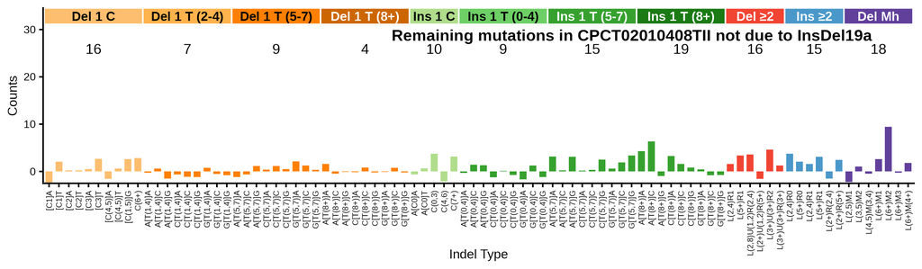

Max neg fraction (maximum allowed negative residual count as fraction of total): 0.08  
N subtract (mutation count assigned to signature): 288.2  
N residual (mutation count in residual “partial spectrum”): 79.8  
Total negative (sum of negative residual mutation counts): 29.4  
N negative channels (number of channels with negative residual): 32  
P(≥ total negative) (Monte Carlo estimated probability that negative-binomial-sampled spectra from the signature contributing N subtract mutations would produce a total negative count >= the observed Total negative; higher number means not surprising): 0.973

**Per-channel residual breakdown**

| Channel | Spectrum | Sig_Count | Residual | Sig_Prop |
| --- | --- | --- | --- | --- |
| [Del(C):R1]A | 4 | 6.4 | -2.4 | 0.02216 |
| [Del(C):R1]T | 9 | 6.9 | 2.1 | 0.02410 |
| [Del(C):R2]A | 4 | 3.8 | 0.2 | 0.01314 |
| [Del(C):R2]T | 5 | 4.8 | 0.2 | 0.01665 |
| [Del(C):R3]A | 3 | 2.5 | 0.5 | 0.00862 |
| [Del(C):R3]T | 5 | 2.3 | 2.7 | 0.00801 |
| [Del(C):R(4,5)]A | 1 | 2.5 | -1.5 | 0.00879 |
| [Del(C):R(4,5)]T | 2 | 1.4 | 0.6 | 0.00487 |
| [Del(C):R(1,5)]G | 6 | 3.4 | 2.6 | 0.01185 |
| Del(C):R(6,9) | 5 | 2.1 | 2.9 | 0.00744 |
| A[Del(T):R(1,4)]A | 6 | 6.3 | -0.3 | 0.02179 |
| A[Del(T):R(1,4)]C | 3 | 2.4 | 0.6 | 0.00827 |
| A[Del(T):R(1,4)]G | 1 | 2.5 | -1.5 | 0.00864 |
| C[Del(T):R(1,4)]A | 3 | 3.7 | -0.7 | 0.01267 |
| C[Del(T):R(1,4)]C | 3 | 4.1 | -1.1 | 0.01432 |
| C[Del(T):R(1,4)]G | 3 | 4.2 | -1.2 | 0.01441 |
| G[Del(T):R(1,4)]A | 3 | 2.2 | 0.8 | 0.00771 |
| G[Del(T):R(1,4)]C | 1 | 1.5 | -0.5 | 0.00522 |
| G[Del(T):R(1,4)]G | 2 | 2.8 | -0.8 | 0.00977 |
| A[Del(T):R(5,7)]A | 0 | 1.2 | -1.2 | 0.00416 |
| A[Del(T):R(5,7)]C | 0 | 0.6 | -0.6 | 0.00217 |
| A[Del(T):R(5,7)]G | 2 | 0.9 | 1.1 | 0.00296 |
| C[Del(T):R(5,7)]A | 1 | 0.6 | 0.4 | 0.00203 |
| C[Del(T):R(5,7)]C | 2 | 0.8 | 1.2 | 0.00287 |
| C[Del(T):R(5,7)]G | 1 | 0.5 | 0.5 | 0.00178 |
| G[Del(T):R(5,7)]A | 3 | 0.9 | 2.1 | 0.00302 |
| G[Del(T):R(5,7)]C | 2 | 0.8 | 1.2 | 0.00263 |
| G[Del(T):R(5,7)]G | 1 | 0.7 | 0.3 | 0.00230 |
| A[Del(T):R(8,)]A | 2 | 0.4 | 1.6 | 0.00143 |
| A[Del(T):R(8,)]C | 0 | 0.5 | -0.5 | 0.00161 |

[output cut: 59 more lines]

## 476-type representations corresponding to InsDel19a

Extracted 476-type signature corresponding to InsDel19a

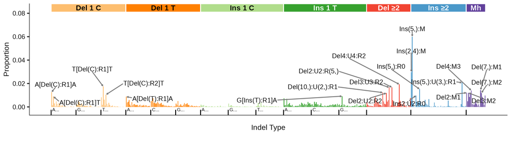

476-type spectrum of the linking tumor CPCT02010408TII; cosine similarity to the extracted 476-type signature is 0.8421

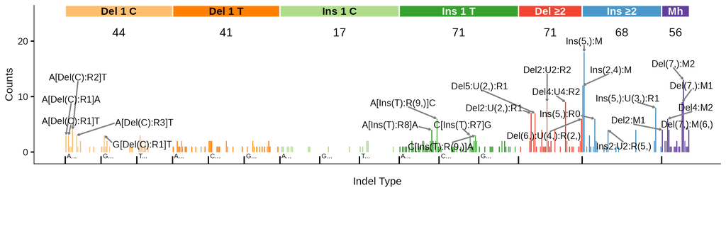

476-type spectrum of best 476-type matching tumor CPCT02010408T; cosine similarity to the extracted 476-type signature is 0.8751

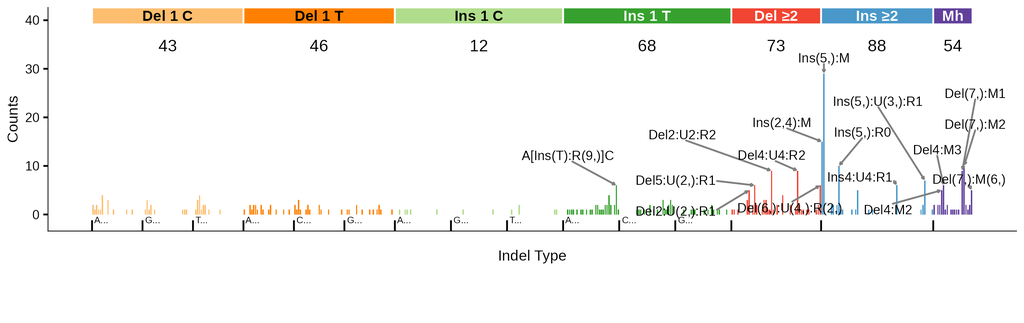

## 83-type signature corresponding to InsDel19a (C_ID19)

**Note**

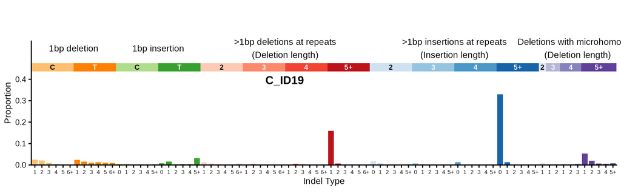

83-type signature converted from signature discovered in the 476-type spectra (using bipartite matching optimization) | cosine similarity to C_ID19: 0.7257

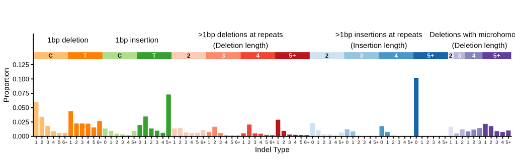

**Click to see flow diagrams: 476-type to 83-type collapse**

These Sankey diagrams show how the 476-type mutation categories are redistributed to 83-type categories using bipartite matching. We only show the diagrams for insertions or deletions of > 1 base because it is for these indels that 476-type categories map to > 1 83-type category.

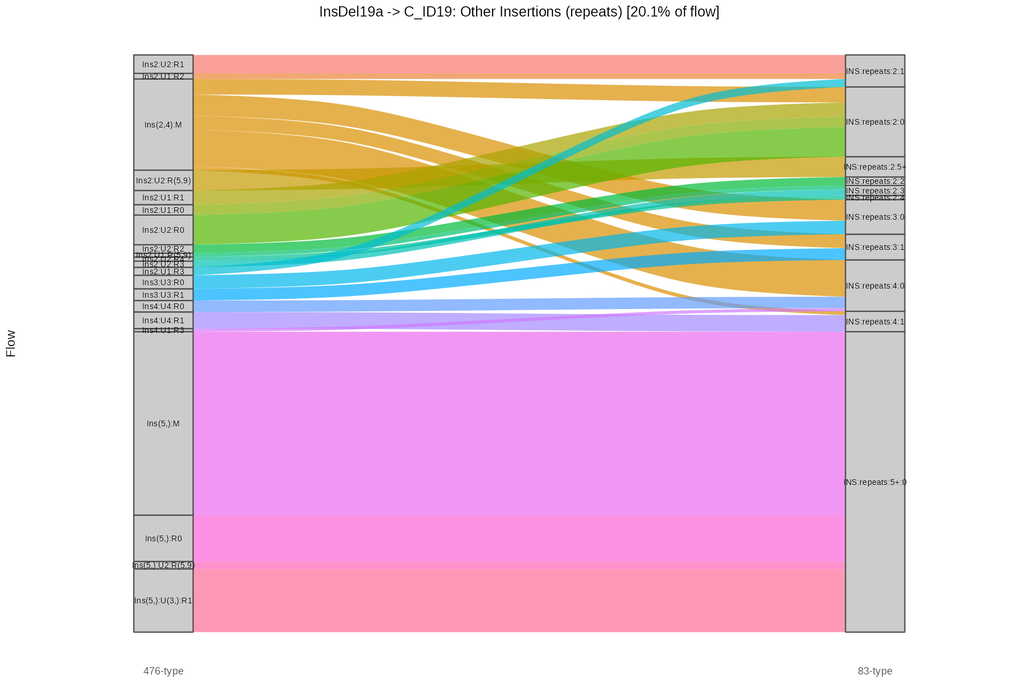

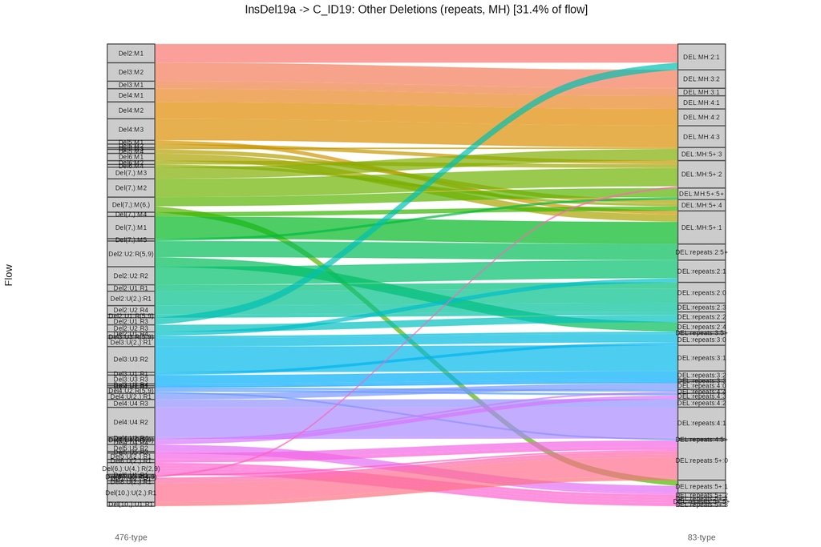

83-type spectrum of the linking tumor CPCT02010408TII | cosine similarity to C_ID19: 0.5483

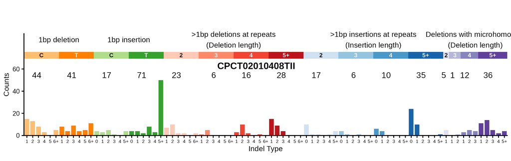

83-type spectrum of best 83-type matching tumor CPCT02080139T | cosine similarity to C_ID19: 0.9895

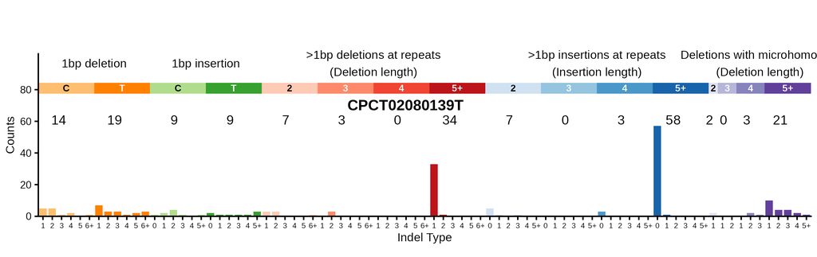